# DATS 6101-11 Introduction to Data Science: First Project

Team 3 : Alejandro, Ebrima, Vidyullatha

2025-10-17

# 1 Introduction

The study will utilize a synthetic dataset (obtained from Kaggle) containing 1,000,000 rows and 6 columns with the variables: student_id, weekly_self_study_hours, attendance_percentage, class_participation, total_score, and grade. With all numerics, except the header row and grade column, makes the data set ideal for exploratory data analysis and deriving insights to understand the performance of each student. By quantifying the data and applying relevant statistical tools such as summary statistics, descriptive statistics, ggplot2 among others, we can better perceive the data and make sound conclusions. There is research that considers other factors of student performance such as nutrition and student performance by Taras Howard (2005); indoor air quality and student performance by the United States Environmental Protection Agency (2003); education resources and student performance by Yaniv, R and Adi, Y (2021). They are all mostly external factors that can affect the performance of a student. Our study narrows the focus down to the internal factors or what could be described as accessible by all students against their total scores.

# 2 Research Topic: Analyse the Factors that Contribute to Student Performance

*SMART Questions of the Research*

1. Do students with attendance ≥ 85% achieve higher average total scores than those with attendance < 85%?
2. Is there a linear relationship between the number of weekly self-study hours and a student’s total_score?
3. Are there any students who dedicate very few hours to studying but still achieve a higher total_score?
4. What are the average weekly study hours, attendance percentage,class participation and total scores for all students in the dataset?
5. Do students with unusually high total_score despite low study hours, attendance, and participation show significant anomalies?

# 3 Summary of the dataset

Load the data set into R.

```r
library(readr)
studperf <- read_csv("./data/StudentsPerformance.csv")
```

Display the first 5 rows

```r
head(studperf, 5)
```

| student_id | weekly_self_study_hours | attendance_percentage | class_participation | total_score | grade |
| --- | --- | --- | --- | --- | --- |
| 1 | 18.5 | 95.6 | 3.8 | 97.9 | A |
| 2 | 14.0 | 80.0 | 2.5 | 83.9 | B |
| 3 | 19.5 | 86.3 | 5.3 | 100.0 | A |
| 4 | 25.7 | 70.2 | 7.0 | 100.0 | A |
| 5 | 13.4 | 81.9 | 6.9 | 92.0 | A |

Structure of dataset (variable types)

```r
str(studperf)
```

```
## spc_tbl_ [1,000,000 × 6] (S3: spec_tbl_df/tbl_df/tbl/data.frame)
##  $ student_id             : num [1:1000000] 1 2 3 4 5 6 7 8 9 10 ...
##  $ weekly_self_study_hours: num [1:1000000] 18.5 14 19.5 25.7 13.4 13.4 26.1 20.4 11.7 18.8 ...
##  $ attendance_percentage  : num [1:1000000] 95.6 80 86.3 70.2 81.9 65.1 81.8 100 100 67.6 ...
##  $ class_participation    : num [1:1000000] 3.8 2.5 5.3 7 6.9 5 5.9 4 8.2 6 ...
##  $ total_score            : num [1:1000000] 97.9 83.9 100 100 92 97.5 100 96.1 69.8 80.3 ...
##  $ grade                  : chr [1:1000000] "A" "B" "A" "A" ...
##  - attr(*, "spec")=
##   .. cols(
##   ..   student_id = col_double(),
##   ..   weekly_self_study_hours = col_double(),
##   ..   attendance_percentage = col_double(),
##   ..   class_participation = col_double(),
##   ..   total_score = col_double(),
##   ..   grade = col_character()
##   .. )
##  - attr(*, "problems")=<externalptr>
```

Basic summary statistics

```r
summary(studperf)
```

```
##    student_id      weekly_self_study_hours attendance_percentage
##  Min.   :      1   Min.   : 0.0            Min.   : 50.0
##  1st Qu.: 250001   1st Qu.:10.3            1st Qu.: 78.3
##  Median : 500000   Median :15.0            Median : 85.0
##  Mean   : 500000   Mean   :15.0            Mean   : 84.7
##  3rd Qu.: 750000   3rd Qu.:19.7            3rd Qu.: 91.8
##  Max.   :1000000   Max.   :40.0            Max.   :100.0
##  class_participation  total_score       grade
##  Min.   : 0.00       Min.   :  9.4   Length:1000000
##  1st Qu.: 4.70       1st Qu.: 73.9   Class :character
##  Median : 6.00       Median : 87.5   Mode  :character
##  Mean   : 5.99       Mean   : 84.3
##  3rd Qu.: 7.30       3rd Qu.:100.0
##  Max.   :10.00       Max.   :100.0
```

Variance, mean, and standard deviation for each column

```r
study_hours_var  <- var(studperf$weekly_self_study_hours, na.rm = T)
study_hours_mean <- mean(studperf$weekly_self_study_hours , na.rm = T)
study_hours_sd   <- sd(studperf$weekly_self_study_hours, na.rm = T)

attendance_var   <- var(studperf$attendance_percentage, na.rm = T)
attendance_mean  <- mean(studperf$attendance_percentage , na.rm = T)
attendance_sd   <- sd(studperf$attendance_percentage, na.rm = T)

participation_var  <- var(studperf$class_participation, na.rm = T)
participation_mean <- mean(studperf$class_participation , na.rm = T)
participation_sd   <- sd(studperf$class_participation, na.rm = T)

total_score_var  <- var(studperf$total_score, na.rm = T)
total_score_mean <- mean(studperf$total_score, na.rm = T)
total_score_sd   <- sd(studperf$total_score, na.rm = T)
```

**Study Hours:** - Variance: 47.602; - Mean: 15.029; - Standard Deviation: 6.899

**Attendance:** - Variance: 88.814; - Mean: 84.711; - Standard Deviation: 9.424

**Participation:** - Variance: 3.828; - Mean: 5.985; - Standard Deviation: 1.956

**Total Score:** - Variance: 238.177; - Mean: 84.284; - Standard Deviation: 15.433

Column names

```r
names(studperf)
```

```
## [1] "student_id"              "weekly_self_study_hours"
## [3] "attendance_percentage"   "class_participation"
## [5] "total_score"             "grade"
```

Unique values

```r
sapply(studperf, function(x) length(unique(x)))
```

```
##              student_id weekly_self_study_hours   attendance_percentage
##                 1000000                     401                     501
##     class_participation             total_score                   grade
##                     101                     824                       5
```

# 4 Descriptive statistics

**How many observations are in this data set?**

```r
#length(studperf)
#nrow(studperf)
dim(studperf)
```

```
## [1] 1000000       6
```

**Answer:** The number of observations in this data set is 1000000.

**How many observations having missing (NA) values?**

```r
sum(is.na(studperf$weekly_self_study_hours))
```

```
## [1] 0
```

```r
sum(is.na(studperf$attendance_percentage))
```

```
## [1] 0
```

```r
sum(is.na(studperf$class_participation))
```

```
## [1] 0
```

```r
sum(is.na(studperf$total_score))
```

```
## [1] 0
```

**Answer:** There are no missing values.

Converting `grade` to a factor variable

```r
studperf$grade <- factor(studperf$grade, levels = c("F","D","C","B","A"), ordered = TRUE)
summary(studperf)
```

```
##    student_id      weekly_self_study_hours attendance_percentage
##  Min.   :      1   Min.   : 0.0            Min.   : 50.0
##  1st Qu.: 250001   1st Qu.:10.3            1st Qu.: 78.3
##  Median : 500000   Median :15.0            Median : 85.0
##  Mean   : 500000   Mean   :15.0            Mean   : 84.7
##  3rd Qu.: 750000   3rd Qu.:19.7            3rd Qu.: 91.8
##  Max.   :1000000   Max.   :40.0            Max.   :100.0
##  class_participation  total_score    grade
##  Min.   : 0.00       Min.   :  9.4   F:  6204
##  1st Qu.: 4.70       1st Qu.: 73.9   D: 44998
##  Median : 6.00       Median : 87.5   C:141980
##  Mean   : 5.99       Mean   : 84.3   B:258174
##  3rd Qu.: 7.30       3rd Qu.:100.0   A:548644
##  Max.   :10.00       Max.   :100.0
```

Looking at new summary statistics nicely: Using the ezids package

```r
studperf_summary <- studperf
colnames(studperf_summary)[1:6]=c("Student ID","Weekly Study Hours","Attendance Percentage","Class Participation","Total Score","Grade")
xkablesummary(studperf_summary)
```

Table: Statistics summary.

|  | Student ID | Weekly Study Hours | Attendance Percentage | Class Participation | Total Score | Grade |
| --- | --- | --- | --- | --- | --- | --- |
| Min | Min. : 1 | Min. : 0.0 | Min. : 50.0 | Min. : 0.00 | Min. : 9.4 | F: 6204 |
| Q1 | 1st Qu.: 250001 | 1st Qu.:10.3 | 1st Qu.: 78.3 | 1st Qu.: 4.70 | 1st Qu.: 73.9 | D: 44998 |
| Median | Median : 500000 | Median :15.0 | Median : 85.0 | Median : 6.00 | Median : 87.5 | C:141980 |
| Mean | Mean : 500000 | Mean :15.0 | Mean : 84.7 | Mean : 5.99 | Mean : 84.3 | B:258174 |
| Q3 | 3rd Qu.: 750000 | 3rd Qu.:19.7 | 3rd Qu.: 91.8 | 3rd Qu.: 7.30 | 3rd Qu.:100.0 | A:548644 |
| Max | Max. :1000000 | Max. :40.0 | Max. :100.0 | Max. :10.00 | Max. :100.0 | NA |

**Findings:** #There are no missing values in the data set #Most of the values fall within the 3rd quartile #Under the Grade column, category A contains more values than any of the other four categories

# 5 Graphical representations of the data

Including Plots

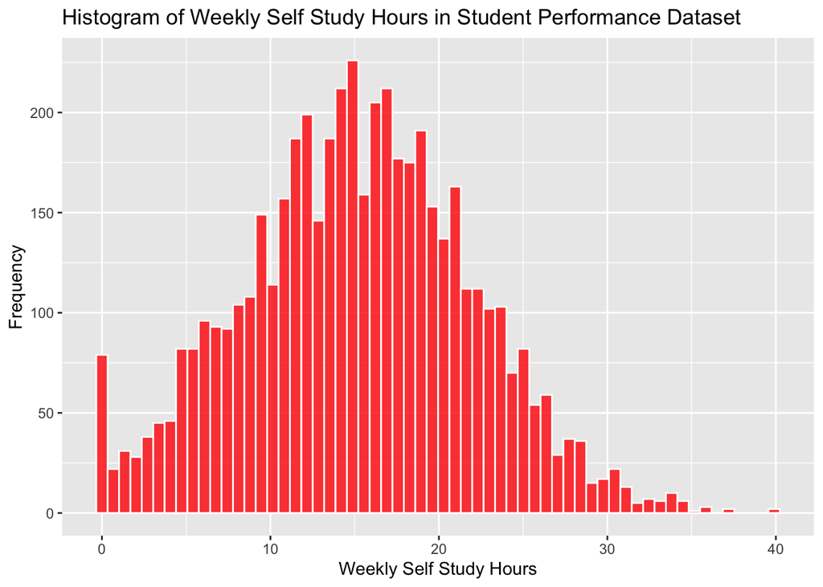

```r
library(ggplot2)

# Downsample for plotting if huge
plot_studperf <- studperf %>% sample_n(min(5000, nrow(studperf)))

ggplot(data=plot_studperf, aes(x=weekly_self_study_hours) ) +
geom_histogram(  col="white",
                 fill="red",
                 alpha = .8, # opacity
                 bins = 60) +
  labs(
        x="Weekly Self Study Hours",
        y="Frequency",
        title="Histogram of Weekly Self Study Hours in Student Performance Dataset")
```

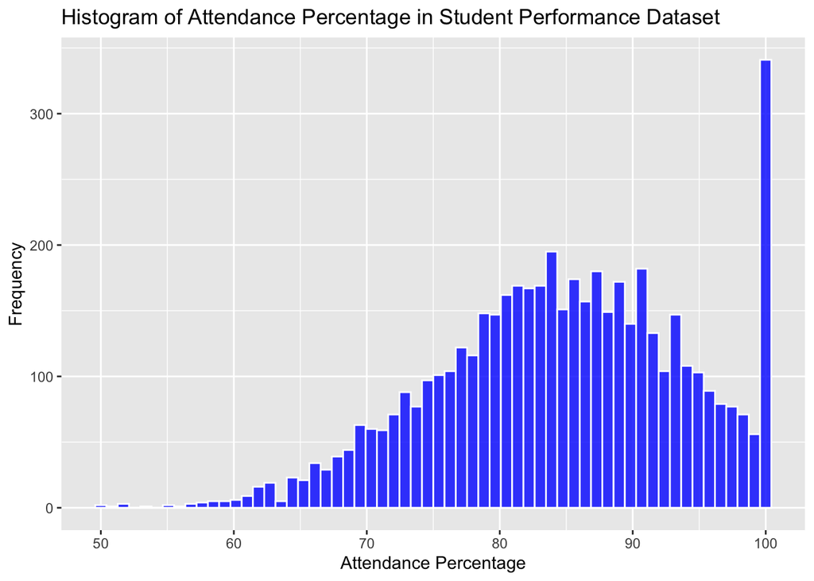

```r
ggplot( data=plot_studperf, aes(x=attendance_percentage) ) +
geom_histogram(  col="white",
                 fill="blue",
                 alpha = .8, # opacity
                 bins = 60) +
  labs(
        x="Attendance Percentage",
        y="Frequency",
        title="Histogram of Attendance Percentage in Student Performance Dataset")
```

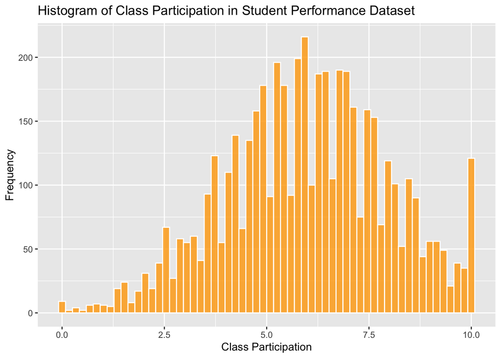

```r
ggplot( data=plot_studperf, aes(x=class_participation) ) +
geom_histogram(  col="white",
                 fill="orange",
                 alpha = .8, # opacity
                 bins = 60) +
  labs(
        x="Class Participation",
        y="Frequency",
        title="Histogram of Class Participation in Student Performance Dataset")
```

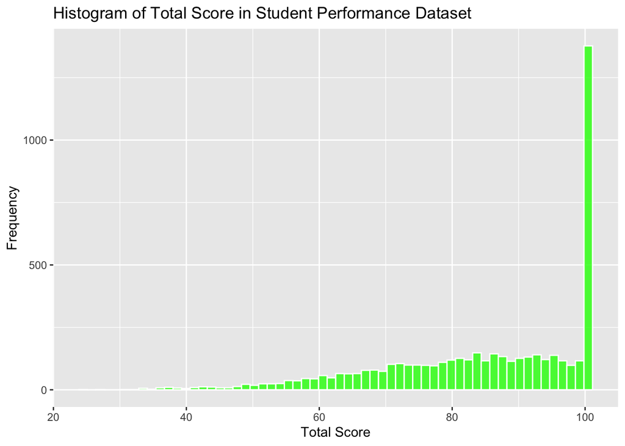

```r
ggplot( data=plot_studperf, aes(x=total_score) ) +
geom_histogram(  col="white",
                 fill="green",
                 alpha = .8, # opacity
                 bins = 60) +
  labs(
        x="Total Score",
        y="Frequency",
        title="Histogram of Total Score in Student Performance Dataset")
```

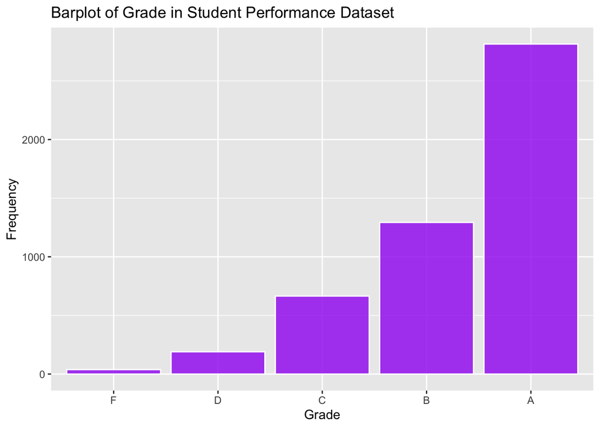

```r
ggplot(plot_studperf, aes(x=grade)) +
  geom_bar( col="white",
                 fill="purple",
                 alpha = .8) +
  labs(
        x="Grade",
        y="Frequency",
        title="Barplot of Grade in Student Performance Dataset")
```

*Outlier Check for the variables: weekly study hours, attendance, class participation and total score respectively. We use the ezids package*

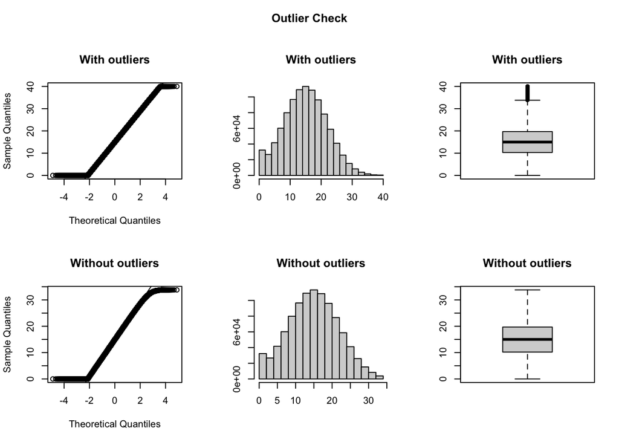

```
## Outliers identified: 3541
## Proportion (%) of outliers: 0.4
## Mean of the outliers: 35.9
## Mean without removing outliers: 15
## Mean if we remove outliers: 15
## Outliers successfully removed
```

```r
studperfclean = outlierKD2(studperf, weekly_self_study_hours, rm = TRUE, boxplt = TRUE, qqplt = TRUE)
```

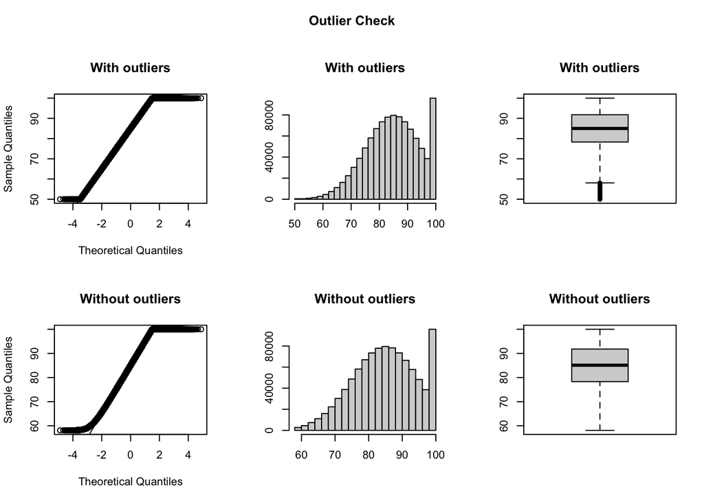

```
## Outliers identified: 3518
## Proportion (%) of outliers: 0.4
## Mean of the outliers: 55.1
## Mean without removing outliers: 84.7
## Mean if we remove outliers: 84.8
## Outliers successfully removed
```

```r
studperfclean2 = outlierKD2(studperfclean, attendance_percentage, rm = TRUE, boxplt = TRUE, qqplt = TRUE)
```

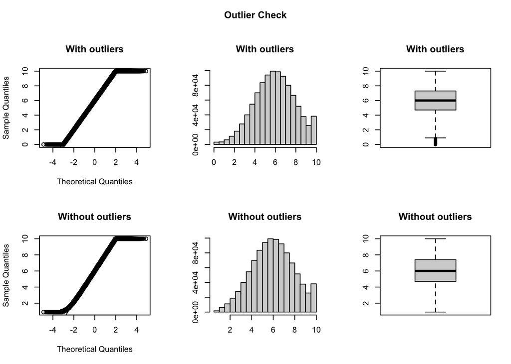

```
## Outliers identified: 4927
## Proportion (%) of outliers: 0.5
## Mean of the outliers: 0.37
## Mean without removing outliers: 5.99
## Mean if we remove outliers: 6.01
## Outliers successfully removed
```

```r
studperfclean3 = outlierKD2(studperfclean2, class_participation, rm = TRUE, boxplt = TRUE, qqplt = TRUE)
```

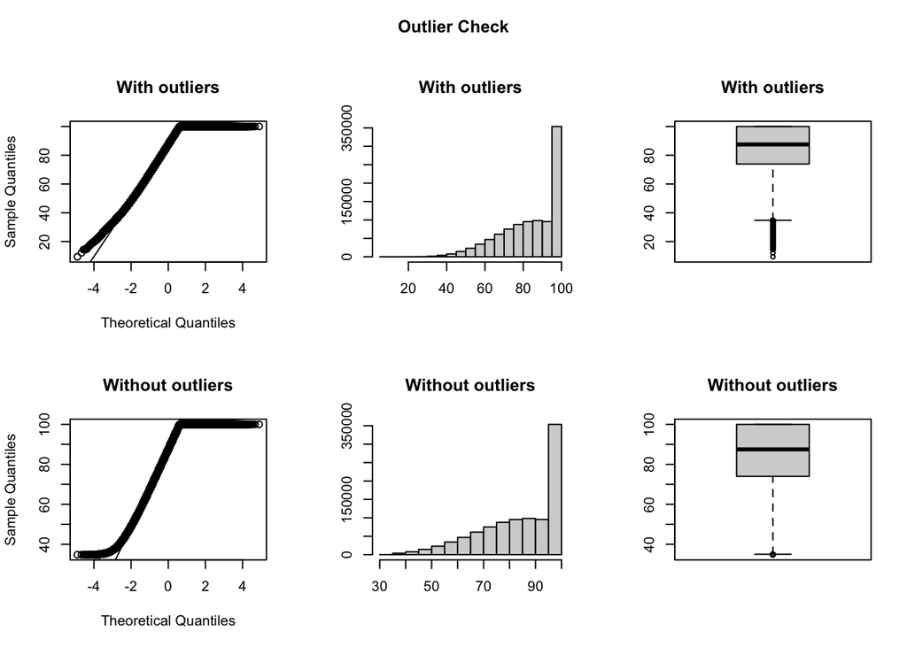

```
## Outliers identified: 2027
## Proportion (%) of outliers: 0.2
## Mean of the outliers: 30.8
## Mean without removing outliers: 84.3
## Mean if we remove outliers: 84.4
## Outliers successfully removed
```

```r
studperfclean4 = outlierKD2(studperfclean3, total_score, rm = TRUE, boxplt = TRUE, qqplt = TRUE)
```

Note: The outliers were replaced by NAs. They were not deleted from the df.

```r
sum(is.na(studperfclean4$weekly_self_study_hours))
```

```
## [1] 3541
```

```r
sum(is.na(studperfclean4$attendance_percentage))
```

```
## [1] 3518
```

```r
sum(is.na(studperfclean4$class_participation))
```

```
## [1] 4927
```

```r
sum(is.na(studperfclean4$total_score))
```

```
## [1] 2027
```

Removing NaN

```r
studperfclean4 <- drop_na(studperfclean4,
                    weekly_self_study_hours,
                    attendance_percentage,
                    class_participation,
                    total_score)

sum(is.na(studperfclean4$weekly_self_study_hours))
```

```
## [1] 0
```

```r
sum(is.na(studperfclean4$attendance_percentage))
```

```
## [1] 0
```

```r
sum(is.na(studperfclean4$class_participation))
```

```
## [1] 0
```

```r
sum(is.na(studperfclean4$total_score))
```

```
## [1] 0
```

Checking the dataframe again:

```r
studperf_summary <- studperfclean4
colnames(studperf_summary)[1:6]=c("Student ID","Weekly Study Hours","Attendance Percentage","Class Participation","Total Score","Grade")
xkablesummary(studperf_summary)
```

Table: Statistics summary.

|  | Student ID | Weekly Study Hours | Attendance Percentage | Class Participation | Total Score | Grade |
| --- | --- | --- | --- | --- | --- | --- |
| Min | Min. : 1 | Min. : 0.0 | Min. : 58.1 | Min. : 0.90 | Min. : 34.8 | F: 4144 |
| Q1 | 1st Qu.: 250040 | 1st Qu.:10.3 | 1st Qu.: 78.3 | 1st Qu.: 4.70 | 1st Qu.: 73.9 | D: 44634 |
| Median | Median : 500066 | Median :15.0 | Median : 85.1 | Median : 6.00 | Median : 87.4 | C:140748 |
| Mean | Mean : 500044 | Mean :15.0 | Mean : 84.8 | Mean : 6.01 | Mean : 84.3 | B:255990 |
| Q3 | 3rd Qu.: 750100 | 3rd Qu.:19.7 | 3rd Qu.: 91.8 | 3rd Qu.: 7.40 | 3rd Qu.:100.0 | A:540534 |
| Max | Max. :1000000 | Max. :33.8 | Max. :100.0 | Max. :10.00 | Max. :100.0 | NA |

# 6 Answering the SMART questions:

### 6.0.1 Q1: Do students with attendance ≥ 85% achieve higher average total scores than those with attendance < 85%?

Creating a categorical variable for attendance

```r
studperfclean4$attendance_group <- ifelse(studperfclean4$attendance_percentage >= 85,
                                   "High (≥85%)", "Low (<85%)")
```

Checking the counts of each group

```r
table(studperfclean4$attendance_group)
```

```
##
## High (≥85%)  Low (<85%)
##      497079      488971
```

Calculating average total scores for high attendance group

```r
high_mean <- mean(subset(studperfclean4, attendance_group == "High (≥85%)")$total_score)
high_mean
```

```
## [1] 84.3
```

Calculating average total scores for low attendace group

```r
low_mean  <- mean(subset(studperfclean4, attendance_group == "Low (<85%)")$total_score)
low_mean
```

```
## [1] 84.3
```

Running t-test to examine the significance and see if this observed difference could have happened just by random chance

```r
t_test_result <- t.test(total_score ~ attendance_group, data = studperfclean4)
t_test_result
```

```
##
##  Welch Two Sample t-test
##
## data:  total_score by attendance_group
## t = -0.7, df = 1e+06, p-value = 0.5
## alternative hypothesis: true difference in means between group High (≥85%) and group Low (<85%) is not equal to 0
## 95 percent confidence interval:
##  -0.0814  0.0391
## sample estimates:
## mean in group High (≥85%)  mean in group Low (<85%)
##                      84.3                      84.3
```

**Answer:** Students with attendance ≥ 85% have an average total score of 84.327, while students with attendance < 85% have an average of 84.348. The t-test p-value is 0.491, which indicates that the difference is not statistically significant. Therefore, students with higher attendance do not necessarily achieve higher total scores in this dataset

### 6.0.2 Q2: Is there a linear relationship between the number of weekly self-study hours and a student’s total_score?

Calculating the correlation between weekly self study hours vs total score

```r
correlation <- cor(studperfclean4$weekly_self_study_hours, studperfclean4$total_score, use = "complete.obs")
correlation
```

```
## [1] 0.815
```

Plot

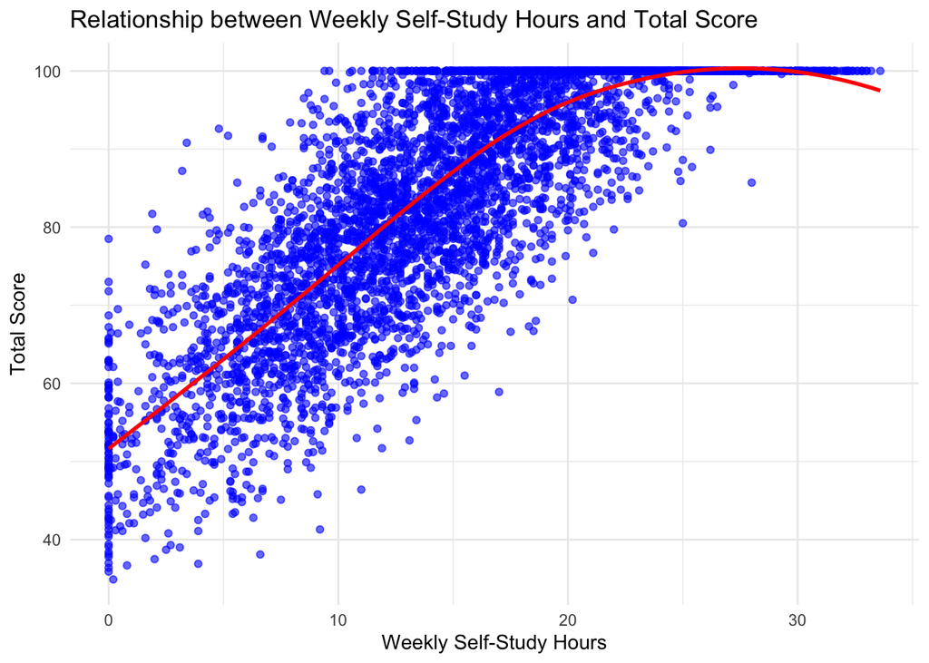

```r
plot_data <- studperfclean4 %>% sample_n(min(5000, nrow(studperfclean4)))
ggplot(plot_data, aes(x = weekly_self_study_hours, y = total_score)) +
  geom_point(color = "blue", alpha = 0.6) +
  geom_smooth(method = "loess", se = FALSE, color = "red") +
  labs(
    title = "Relationship between Weekly Self-Study Hours and Total Score",
    x = "Weekly Self-Study Hours",
    y = "Total Score"
  ) +
  theme_minimal()
```

**Answer:** The correlation coefficient between weekly self-study hours and total score is 0.815. This value suggests a positive relationship, meaning that as weekly self-study hours increase, total scores tend to increase.

The scatter plot further supports this trend, showing that students who spend more time studying generally achieve higher total scores.  
However, correlation does **not imply causation**, and while there appears to be a linear pattern, other factors may also influence performance.

### 6.0.3 Q3: Are there any students who dedicate very few hours to studying but still achieve a higher total_score?

```r
# cutoffs
low_hours  <- quantile(studperfclean4$weekly_self_study_hours, 0.20, na.rm=TRUE)
high_score <- quantile(studperfclean4$total_score, 0.90, na.rm=TRUE)

# pick the students
few_but_high <- subset(studperfclean4,
  weekly_self_study_hours <= low_hours & total_score >= high_score)

nrow(few_but_high); head(few_but_high)
```

```
## [1] 164
```

| student_id | weekly_self_study_hours | attendance_percentage | class_participation | total_score | grade | attendance_group |
| --- | --- | --- | --- | --- | --- | --- |
| 838 | 8.0 | 68.7 | 9.8 | 100 | A | Low (<85%) |
| 3854 | 7.2 | 100.0 | 8.6 | 100 | A | High (≥85%) |
| 8459 | 8.9 | 73.0 | 9.0 | 100 | A | Low (<85%) |
| 9219 | 8.7 | 98.1 | 5.3 | 100 | A | High (≥85%) |
| 18249 | 5.4 | 74.2 | 4.3 | 100 | A | Low (<85%) |
| 18839 | 8.1 | 78.9 | 6.6 | 100 | A | Low (<85%) |

**Answer:** Yes 164 is > 0, so there are students who study very little (≤ 20th percentile of hours) and still score very high (≥ 90th percentile).

### 6.0.4 Q4 : What are the average weekly study hours, attendance percentage, class participation, and total scores for all students in the dataset?

Average for each column

```r
study_hours_mean <- mean(studperfclean4$weekly_self_study_hours , na.rm = T)
attendance_mean  <- mean(studperfclean4$attendance_percentage , na.rm = T)
participation_mean <- mean(studperfclean4$class_participation , na.rm = T)
total_score_mean <- mean(studperfclean4$total_score, na.rm = T)
```

**Answer:** Average of Weekly Study Hours, Attendance Percentage, Class Participation, and Total Scores are 14.984, 84.815, 6.013, 84.338 respectively.

### 6.0.5 Q5: Do students with unusually high total_score despite low study hours, attendance, and participation show significant anomalies?

```r
# low-effort = bottom 20% on all three
q <- with(studperfclean4, data.frame(
  study = quantile(weekly_self_study_hours, 0.20, na.rm=TRUE),
  att   = quantile(attendance_percentage,   0.20, na.rm=TRUE),
  part  = quantile(class_participation,     0.20, na.rm=TRUE)
))

# Using subset
low <- subset(studperfclean4,
  weekly_self_study_hours <= q$study &
  attendance_percentage   <= q$att   &
  class_participation     <= q$part)

# Unusually High = top ~2.3% within LOW group (≈ Z > 2 equivalent)
cut97 <- quantile(low$total_score, 0.977, na.rm=TRUE)
low$anomaly <- low$total_score > cut97

n_low   <- nrow(low)
cutoff  <- as.numeric(cut97)
observed<- sum(low$anomaly)
rate    <- mean(low$anomaly) * 100
```

Low-effort and high scorers

We defined low effort as the bottom 20% on study hours, attendance, and participation, and flagged “unusually high” total_score as above the 97.7th percentile within that low-effort group.

Total low-effort students: 7878 High-score cutoff (97.7th pct): 87.3 Anomalies found: 179 students Rate: 2.27%

This small percentage shows these students are rare outliers, not a common pattern.

# 7 Reflections and Limitations

The analysis provides several insights into student performance. We observed a strong positive correlation (r = 0.815) between weekly self-study hours and total scores, indicating that students who dedicate more time to self-study tend to achieve higher scores. The identification of low-effort yet high-performing students highlights that there are exceptional cases, suggesting that factors beyond study hours, attendance, and participation may influence performance, such as prior knowledge or learning strategies.

**Limitations of the dataset and analysis:**

- The dataset is cross-sectional; therefore, causality cannot be inferred from correlations or t-tests.
- Outlier removal was necessary to stabilize the analysis; however, this may slightly bias averages or variability.
- Certain variables, such as `grade`, are categorical summaries of continuous performance and may hide subtle variations.
- The dataset lacks information on student demographics, prior academic performance, or socioeconomic status, which could influence outcomes.
- Statistical tests assume approximate normality of distributions; although the dataset is large, non-normality in some variables could affect small-effect comparisons.

**Future improvements:**

- Collect longitudinal data to better understand causality between study behaviors and performance.
- Include additional explanatory variables (e.g., study environment, prior grades) to improve predictive insights.
- Explore advanced modeling techniques such as multiple regression or mixed-effects models to account for multiple influencing factors simultaneously.

This reflection helps contextualize the analysis, acknowledges potential biases, and suggests directions for further research.

**References:**

- Taras, H. (2005), Nutrition and Student Performance at School. Journal of School Health, 75: 199-213. https://doi.org/10.1111/j.1746-1561.2005.tb06674.x
- United States Environmental Protection Agency (2003). Indoor Environmental Division. Indoor Air Quality & Student Performance. Washington, D.C: U.S.
- Yaniv, R. and Shany, A. (2021), “Education Resources and Student Performance: Evidence from Arab Municipalities in Israel.” Applied economics 53.38): 4386–4403.
- Nabeel, G.M (n.d). Student Performance Dataset (Synthetic, Realistic). Kaggle